# Scripts for Paired yeast one-hybrid assays to detect DNA-binding cooperativity and antagonism across transcription factors

Zhaorong Li

# 1 Read in Count Matrix

The first step is to read in a expression matrix. The rows of the count matrix are gene names and the columns of the count matrix are samples or aggregated samples (depending on the experiment design and data types).

In this case the data set is CPM normalized. But any type of normalization is supported.

```r
CountMatrix=read.table('Tissue_Celltype.CPM.tsv',header = T,row.names = 1,sep = '\t',check.names = F)

head(CountMatrix,n = c(5,5))
```

```
##       Bladder_CD8 T Cells Bladder_Stromal Cells Bladder_Epithelial Cells
## MAX              495.0406            635.907764                 17.36284
## NR1H3             12.6367            406.558443                  9.04028
## PIN1             455.6297           1091.002988                 35.48143
## GATA1              0.0000              2.021513                  0.00000
## RELA             360.6949            622.686452                 32.39716
##       Bladder_CD4 T Cells Bladder_Smooth Muscle Cells
## MAX              452.5713                    79.91721
## NR1H3              6.9465                    13.78887
## PIN1             379.7030                   240.85677
## GATA1              0.0000                     0.00000
## RELA             293.6176                    69.14610
```

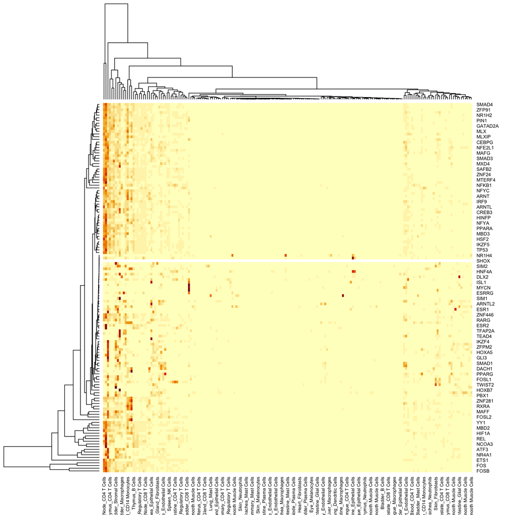

```r
heatmap((((as.matrix(CountMatrix)))))
```

# 2 Build Binary Expression Matrix

The binary expression matrix is calculated based on the expression matrix.  
The rows of the binary expression matrix are genes and the columns are samples or aggregated samples, just like the expression matrix.

The Binary Matrix is used to determined whether a gene is “expressed’ in a sample. This information will be used to evaluating of the expression pattern among samples later.

```r
Binary=data.frame(matrix(rep(0,nrow(CountMatrix)*ncol(CountMatrix)),nrow = nrow(CountMatrix),dimnames = list(rownames(CountMatrix),colnames(CountMatrix))))

for (i in 1:nrow(Binary)) {
  threshold=max(CountMatrix[i,])*(0.1)
  Binary[i,]=ifelse(CountMatrix[i,]>=threshold,yes=1,no=0)
}

head(Binary,n = c(5,5))
```

```
##       Bladder_CD8.T.Cells Bladder_Stromal.Cells Bladder_Epithelial.Cells
## MAX                     1                     1                        0
## NR1H3                   0                     1                        0
## PIN1                    1                     1                        0
## GATA1                   0                     0                        0
## RELA                    1                     1                        0
##       Bladder_CD4.T.Cells Bladder_Smooth.Muscle.Cells
## MAX                     1                           0
## NR1H3                   0                           0
## PIN1                    1                           1
## GATA1                   0                           0
## RELA                    1                           0
```

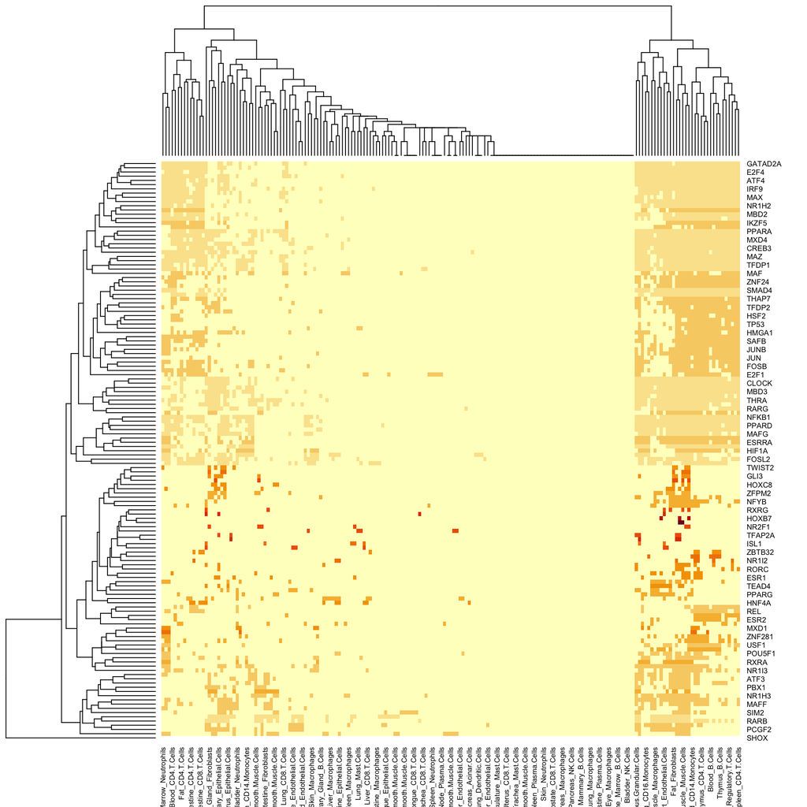

```r
heatmap((((as.matrix(Binary)))))
```

# 3 Evaluate the coexpression and diversity of genes among samples.

For every pair of TFs, the following results are calculated:  
Number of samples expressing the TF1 in the pair  
Number of samples expressing the TF2 in the pair  
Number of samples expressing both TF1 and TF2 in the pair  
Jaccard Index of the two TFs  
Simpson Index of the two TFs

```r
interactions=read.table('interactions.tsv',header = T)

interactions$TF1.presence=0
interactions$TF2.presence=0
interactions$TFs.copresence=0
interactions$Jaccard.Index=0
interactions$Simpson.Index=0


for (i in 1:nrow(interactions)) {
  TF1=Binary[interactions$TF1[i],]
  TF2=Binary[interactions$TF2[i],]
  interactions$TF1.presence[i]=sum(TF1==1)
  interactions$TF2.presence[i]=sum(TF2==1)
  interactions$TFs.copresence[i]=length(intersect(names(TF1)[TF1==1],names(TF2)[TF2==1]))
  interactions$Jaccard.Index[i]=length(intersect(names(TF1)[TF1==1],names(TF2)[TF2==1]))/length(unique(c(names(TF1)[TF1==1],names(TF2)[TF2==1])))
  interactions$Simpson.Index[i]=length(intersect(names(TF1)[TF1==1],names(TF2)[TF2==1]))/min(c(length(names(TF2)[TF2==1]),
                                                                                               length(names(TF1)[TF1==1])))

}

head(interactions)
```

```
##     TF1   TF2 TF1.presence TF2.presence TFs.copresence Jaccard.Index
## 1   MAX  MXD3           46            7              7     0.1521739
## 2   MAX  MXI1           46           45             38     0.7169811
## 3 NR1H3  RXRG           35            6              4     0.1081081
## 4  PIN1  TP53           57           22             22     0.3859649
## 5 GATA1 ZFPM2            5           17              0     0.0000000
## 6  RELA TEAD4           58           12             11     0.1864407
##   Simpson.Index
## 1     1.0000000
## 2     0.8444444
## 3     0.6666667
## 4     1.0000000
## 5     0.0000000
## 6     0.9166667
```

```r
write.table(interactions,'interactions.analyzed.tsv',quote = F,sep = '\t',row.names = F)
```